SOL512 · Probabilidad e Inferencia para Estadística Social

# Ayudantía 5: Intervalos de Confianza y Método Bootstrap

Vicente Mühlenbrock · v.muhlenbrock@uc.cl

## Intervalos de Confianza

Teoría, construcción y aplicaciones

I

## ¿Qué es un Intervalo de Confianza?

Cuando estimamos $\bar{X}$ a partir de una muestra, obtenemos el mejor estimado puntual de $\mu$, pero ese valor *cambia con cada muestra*. El **intervalo de confianza (IC)** captura esa incertidumbre: en lugar de un punto, entrega un rango de valores plausibles para $\mu$.

**Definición.** El IC al $100(1-\alpha)\%$ es el intervalo $\bigl[\bar{X} - Z_{\alpha/2}\cdot\frac{\sigma}{\sqrt{n}},\;\bar{X} + Z_{\alpha/2}\cdot\frac{\sigma}{\sqrt{n}}\bigr]$ construido de modo que el $100(1-\alpha)\%$ de los intervalos generados por este procedimiento —sobre infinitas muestras— **contienen al verdadero parámetro $\mu$**.

**Interpretación correcta.** $\mu$ es fijo; lo aleatorio es $\bar{X}$ y, por tanto, el intervalo mismo. Un IC ya calculado o contiene a $\mu$ o no lo contiene: no tiene probabilidad propia.

**Analogía.** Cada IC es una “red de pesca”: la lanzamos sin saber dónde está el pez ($\mu$). Con 95 % de confianza, 95 de cada 100 redes capturan el pez.

Figura: 20 muestras → 20 IC al 95 %. Los rojos *no* capturan μ.

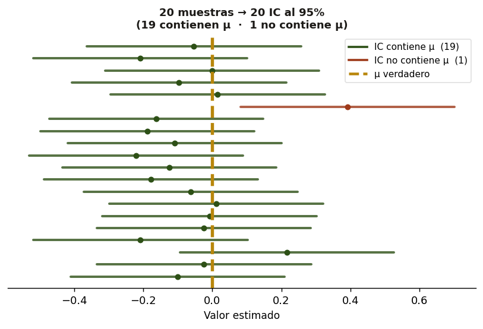

## Componentes del IC y el Valor Crítico

$$\bar{X} \;\pm\; \underbrace{Z_{\alpha/2}}_{\text{valor cr\'itico}} \;\cdot\; \underbrace{\dfrac{\sigma}{\sqrt{n}}}_{\text{SE}}$$

**Valor crítico $Z_{\alpha/2}$.** Es el umbral de la distribución normal estándar que deja exactamente $\alpha/2$ de probabilidad en cada cola. Indica cuántas desviaciones estándar hay que alejarse de la media para abarcar el $1-\alpha$ central. A mayor nivel de confianza deseado, mayor $Z_{\alpha/2}$ y más ancho el IC.

### Valores críticos habituales

| $\alpha$ | Confianza | $Z_{\alpha/2}$ | En R |
| --- | --- | --- | --- |
| 0.01 | 99 % | 2.576 | `qnorm(0.995)` |
| 0.05 | 95 % | 1.960 | `qnorm(0.975)` |
| 0.10 | 90 % | 1.645 | `qnorm(0.950)` |

$\downarrow\alpha \Rightarrow \uparrow Z_{\alpha/2}$ → IC más **ancho** (más confianza, menos preciso).

$\uparrow n \Rightarrow \downarrow\sigma/\!\sqrt{n}$ → IC más **estrecho** (misma confianza, más preciso).

Figura: región azul = 95 % del área; colas rojas = $\alpha/2$ cada una. Los cortes verticales son los **valores críticos** ±1.96.

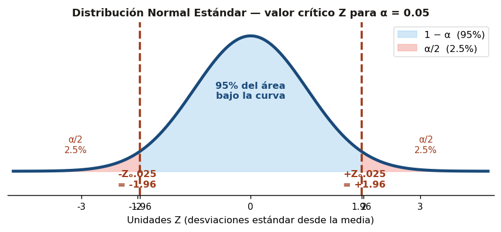

## IC para Proporciones Variable binaria

**¿Cuándo aplica?** Muchas variables en ciencias sociales son dicotómicas: votó / no votó, tiene título / no tiene, está empleado / no. Queremos estimar la *proporción poblacional* $p = P(X=1)$ con la proporción muestral $\hat{p} = \bar{X}$. Para construir el IC necesitamos la distribución muestral de $\hat{p}$, lo que requiere conocer la varianza de la Bernoulli.

### Distribución muestral de $\hat{p}$

Cada $X_i \sim \text{Bernoulli}(p)$, con $\mathbb{E}(X)=p$ y $\text{Var}(X)=p(1-p)$.

Por el **TLC**, para $n$ grande ($np>5$ y $n(1-p)>5$):

$$\hat{p} \;\overset{d}{\longrightarrow}\; \mathcal{N}\!\left(p,\;\frac{\sqrt{p(1-p)}}{\sqrt{n}}\right)$$

**SE de $\hat{p}$:** $\;\text{SE} = \sqrt{\hat{p}(1-\hat{p})/n}$  
$p$ desconocido se sustituye por $\hat{p}$ (*plug-in*).

$$\hat{p} \pm Z_{\alpha/2}\cdot\sqrt{\frac{\hat{p}(1-\hat{p})}{n}}$$

**Misma estructura** que IC para medias: $\hat{\theta} \pm Z_{\alpha/2}\cdot\text{SE}$. Solo cambia el SE.

### Varianza de la Bernoulli

$p(1-p)$ determina el SE. Es máxima en $p=0.5$, base del diseño muestral conservador.

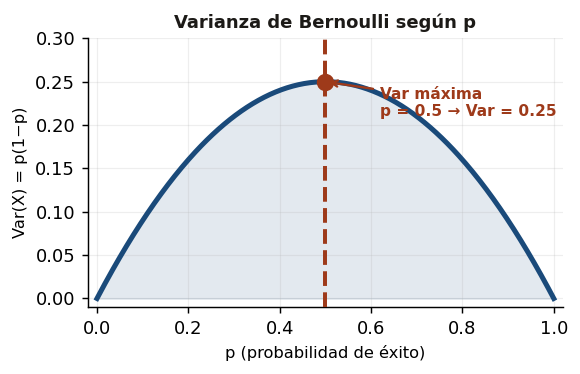

**Varianza máxima:** $p=0.5 \Rightarrow p(1-p)=0.25$. Usada cuando $p$ es desconocido.

## IC con Varianza Desconocida & Margen de Error

### El estimador insesgado $s^2$

**¿Qué es un estimador insesgado?** Un estimador $\hat{\theta}$ es *insesgado* si $\mathbb{E}[\hat{\theta}]=\theta$: promediado sobre muchas muestras, apunta al valor correcto sin sobre- ni subestimarlo sistemáticamente.

El estimador *naive* $\frac{1}{n}\sum(x_i-\bar{x})^2$ subestima $\sigma^2$:

$$\mathbb{E}\!\left[\frac{1}{n}\sum(x_i-\bar{x})^2\right] = \sigma^2\cdot\frac{n-1}{n} < \sigma^2$$

La **corrección de Bessel** (dividir por $n-1$, grados de libertad) lo corrige:

$$s^2 = \frac{1}{n-1}\sum_{i=1}^{n}(x_i-\bar{x})^2 \;\Rightarrow\; \mathbb{E}[s^2]=\sigma^2$$

En R, `sd(x)` usa $n-1$ automáticamente. $\text{SE}=s/\sqrt{n}$.

### Margen de Error

**¿Qué es el margen de error?** Es el semiancho del IC: la cantidad que se suma y resta al estimador central. Cuantifica la imprecisión derivada de la variabilidad muestral. En encuestología se reporta junto al nivel de confianza (“±3 pp al 95 %”). **No existe un ME único para toda la encuesta**: cada variable tiene el suyo.

$$\text{ME} = Z_{\alpha/2}\cdot\frac{\sigma}{\sqrt{n}}$$

Despejando $n$ para diseño muestral (95 % conf., var. máx.):

$$n = \frac{Z_{\alpha/2}^2\cdot\sigma^2}{\text{ME}^2} \;\approx\; \frac{1}{\text{ME}^2}$$

ME = 2 % ⇒ $n \approx 2{,}500$ · ME = 3 % ⇒ $n \approx 1{,}111$ · ME = 5 % ⇒ $n \approx 400$

## Ejemplo: IC para el Ingreso de Mujeres (CASEN 2017)

**Enunciado.** Muestra de $n=2{,}114$ mujeres. Media muestral: $\bar{X}=233{,}405$ pesos. Desv. estándar poblacional conocida: $\sigma=583{,}454$ pesos. Calcule IC al 99 %, 95 % y 90 % de confianza.

1

**Error estándar (SE)**  
$\displaystyle\text{SE}=\frac{\sigma}{\sqrt{n}}=\frac{583{,}454}{\sqrt{2{,}114}}=\frac{583{,}454}{45{,}98}\approx\mathbf{12{,}688}$ pesos

2

**Valores críticos**  
99 %: $Z_{0.005}=2{,}576$ · 95 %: $Z_{0.025}=1{,}960$ · 90 %: $Z_{0.05}=1{,}645$

3

**Límites IC 99 %**: $233{,}405 \pm 2{,}576\!\times\!12{,}688=\mathbf{(200{,}720\;;266{,}090)}$

4

**Límites IC 95 %**: $233{,}405 \pm 1{,}960\!\times\!12{,}688=\mathbf{(208{,}537\;;258{,}273)}$

5

**Límites IC 90 %**: $233{,}405 \pm 1{,}645\!\times\!12{,}688=\mathbf{(212{,}533\;;254{,}277)}$

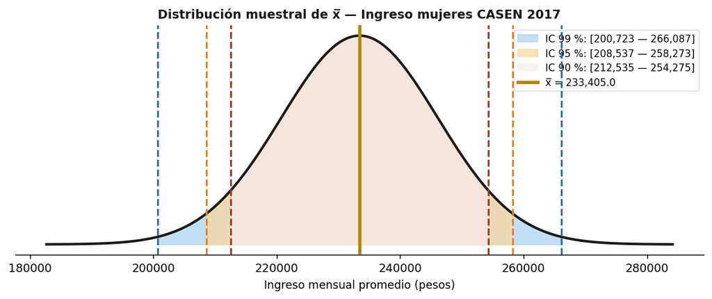

## Ejercicio 1: Salario de Trabajadores Informales Ejercicio

**Enunciado.** En una región, se encuesta a $n=350$ trabajadores del sector informal. El salario mensual promedio muestral es $\bar{X}=485{,}000$ pesos. La desviación estándar poblacional es conocida: $\sigma=98{,}000$ pesos. Construya IC al 90 %, 95 % y 99 % de confianza para el salario promedio.

**Paso 1 — SE:** $\text{SE} = \dfrac{\sigma}{\sqrt{n}} = \dfrac{98{,}000}{\sqrt{350}} = \dfrac{98{,}000}{18{,}71} \approx \mathbf{5{,}238}$ pesos

**Paso 2 — Valores críticos:** 99 %: 2.576 · 95 %: 1.960 · 90 %: 1.645

**IC 99 %:** $485{,}000 \pm 2{,}576\times5{,}238 = \mathbf{(471,506\;;498,494)}$

**IC 95 %:** $485{,}000 \pm 1{,}960\times5{,}238 = \mathbf{(474,733\;;495,267)}$

**IC 90 %:** $485{,}000 \pm 1{,}645\times5{,}238 = \mathbf{(476,383\;;493,617)}$

Código R

```r
mu <- 485000; sigma <- 98000; n <- 350
SE <- sigma / sqrt(n)           # 5238
for (conf in c(0.90, 0.95, 0.99)) {
  z  <- qnorm(1 - (1-conf)/2)
  ic <- round(mu + c(-1,1)*z*SE, 0)
  cat("IC", conf*100, "%:", ic, "\n")
}
```

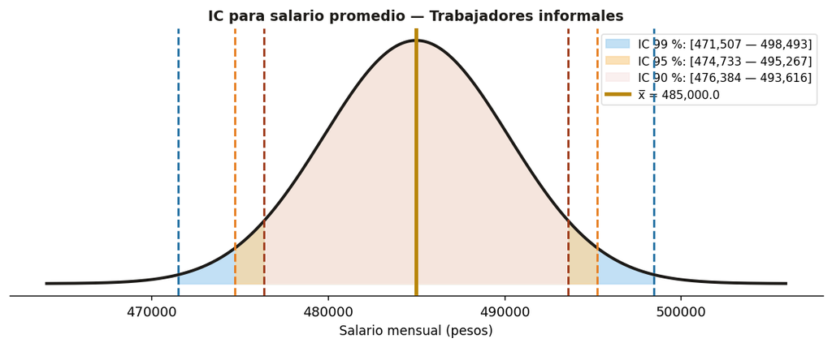

## Ejercicio 2: Hogares bajo Línea de Pobreza Ejercicio

**Enunciado.** En una ciudad, se entrevistan $n=1{,}200$ hogares. Un 18{,}7 % declara ingresos bajo la línea de pobreza ($\hat{p}=0{,}187$). Construya IC al 90 %, 95 % y 99 % de confianza para la proporción de hogares en situación de pobreza.

**Paso 1 — SE:** $\text{SE} = \sqrt{\dfrac{\hat{p}(1-\hat{p})}{n}} = \sqrt{\dfrac{0{,}187\times0{,}813}{1{,}200}} \approx \mathbf{0{,}01127}$

**Paso 2 — Valores críticos:** 99 %: 2.576 · 95 %: 1.960 · 90 %: 1.645

**IC 99 %:** $0{,}187 \pm 2{,}576\times0{,}01127 = \mathbf{(0.1580\;;0.2160)}$

**IC 95 %:** $0{,}187 \pm 1{,}960\times0{,}01127 = \mathbf{(0.1649\;;0.2091)}$

**IC 90 %:** $0{,}187 \pm 1{,}645\times0{,}01127 = \mathbf{(0.1685\;;0.2055)}$

Código R

```r
p_hat <- 0.187; n <- 1200
SE <- sqrt(p_hat * (1 - p_hat) / n)
for (conf in c(0.90, 0.95, 0.99)) {
  z  <- qnorm(1 - (1-conf)/2)
  ic <- round(p_hat + c(-1,1)*z*SE, 4)
  cat("IC", conf*100, "%:", ic, "\n")
}
```

[figure not shown]

## Ejercicio 3: Escolaridad en Zonas Rurales Ejercicio

**Enunciado.** Se encuestan $n=180$ jóvenes (15–24 años) en comunas rurales. El promedio de años de escolaridad es $\bar{X}=9{,}4$ años. La desviación estándar poblacional es $\sigma=2{,}8$ años. Construya IC al 90 %, 95 % y 99 % de confianza.

**Paso 1 — SE:** $\text{SE} = \dfrac{\sigma}{\sqrt{n}} = \dfrac{2{,}8}{\sqrt{180}} = \dfrac{2{,}8}{13{,}42} \approx \mathbf{0{,}2087}$ años

**Paso 2 — Valores críticos:** 99 %: 2.576 · 95 %: 1.960 · 90 %: 1.645

**IC 99 %:** $9{,}4 \pm 2{,}576\times0{,}2087 = \mathbf{(8.86\;;9.94)}$ años

**IC 95 %:** $9{,}4 \pm 1{,}960\times0{,}2087 = \mathbf{(8.99\;;9.81)}$ años

**IC 90 %:** $9{,}4 \pm 1{,}645\times0{,}2087 = \mathbf{(9.06\;;9.74)}$ años

Código R

```r
mu <- 9.4; sigma <- 2.8; n <- 180
SE <- sigma / sqrt(n)
for (conf in c(0.90, 0.95, 0.99)) {
  z  <- qnorm(1 - (1-conf)/2)
  ic <- round(mu + c(-1,1)*z*SE, 2)
  cat("IC", conf*100, "%:", ic, "\n")
}
```

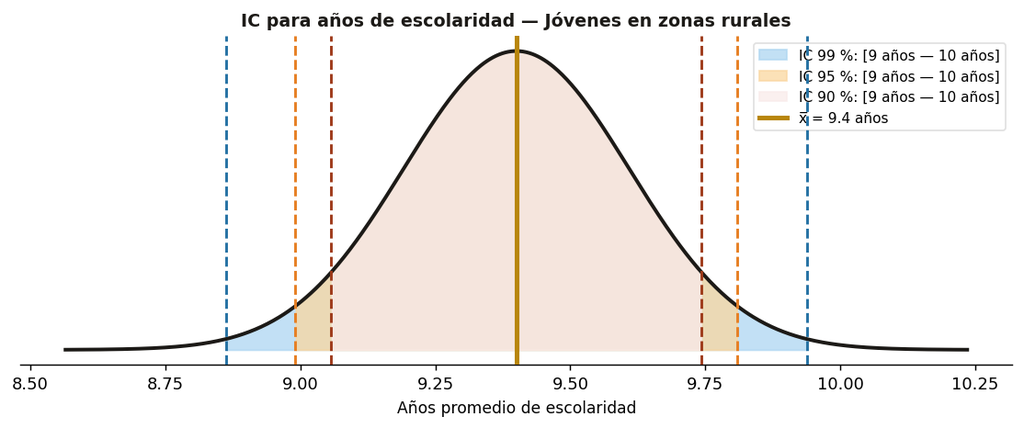

## Cálculo de IC en R echo = TRUE

IC para media (σ conocida) y varianza estimada

```r
## Datos y media muestral
mu  <- mean(casen$ingreso, na.rm = TRUE)

## IC con sigma conocida (sigma = 583454)
n    <- sum(!is.na(casen$ingreso))    # 2114
SE   <- 583454 / sqrt(n)              # 12688

ic99 <- mu + qnorm(c(0.005, 0.995)) * SE
ic90 <- mu + qnorm(c(0.05,  0.95 )) * SE
cat("IC 99%:", round(ic99, 0), "\n")
cat("IC 90%:", round(ic90, 0), "\n")

## IC con varianza estimada (s^2, divide por n-1)
s    <- sd(casen$ingreso, na.rm = TRUE)
SE_s <- s / sqrt(n)
ic95s <- mu + qnorm(c(0.025, 0.975)) * SE_s
cat("IC 95% (s estimada):", round(ic95s, 0), "\n")
```

## IC 99%: 200720 266090  
## IC 90%: 212533 254277  
## IC 95% (s estimada): 208012 258798

IC para proporción muestral

```r
## Proporcion mujeres universitarias (>27 anos)
p_hat <- mean(casen$univ, na.rm = TRUE)  # 0.1977
n_u   <- sum(!is.na(casen$univ))

SE_p  <- sqrt(p_hat * (1 - p_hat)) / sqrt(n_u)

ic99p <- p_hat + qnorm(c(0.005, 0.995)) * SE_p
ic90p <- p_hat + qnorm(c(0.05,  0.95 )) * SE_p
cat("IC 99%:", round(ic99p, 4), "\n")
cat("IC 90%:", round(ic90p, 4), "\n")
```

**Nota.** `sd()` en R divide por $n-1$ automáticamente. Equivalente manual: `sqrt(sum((x-mean(x))^2, na.rm=T) / (n-1))`.

## Método Bootstrap

Inferencia estadística por simulación computacional

II

## Bootstrap: Fundamento Teórico

**El problema.** Los IC basados en el TLC requieren conocer la distribución muestral de $\hat{\theta}$. Para $\bar{X}$ eso es directo. Para la *mediana, cuantiles, razón de medias, coeficientes de Gini* u otros estadísticos complejos, esa distribución puede ser desconocida o muy difícil de derivar analíticamente.

### La idea central

Si conociéramos $F$ (la distribución poblacional), podríamos simular infinitas muestras de tamaño $n$, calcular $\hat{\theta}$ en cada una y observar directamente su variabilidad. Como $F$ es desconocida, la **reemplazamos por la distribución empírica $\hat{F}$**, que asigna probabilidad $1/n$ a cada observación de la muestra. Muestrear de $\hat{F}$ es exactamente lo mismo que **remuestrear con reemplazo** de la muestra original.

**¿Por qué funciona?** Por la Ley de Grandes Números: para $n$ suficientemente grande, $\hat{F} \approx F$. La distribución bootstrap de $\hat{\theta}$ aproxima la verdadera distribución muestral. Cuanto mayor $B$, más estable la aproximación.

### Algoritmo en 5 pasos

1

**Remuestra con reemplazo:** extraí $n$ observaciones aleatoriamente de la muestra original, permitiendo repeticiones. Esta es la *muestra bootstrap* $X_b$.

2

**Aplica el estimador:** calcula $\hat{\theta}_b = \theta(X_b)$. Puede ser media, mediana, varianza, cuantil o cualquier función de los datos.

3

**Repite $B$ veces:** ejecuta pasos 1–2 un número grande de veces (típicamente $B=1{,}000$ a $5{,}000$). Cada iteración produce un valor $\hat{\theta}_b$.

4

**Distribución bootstrap:** los $B$ valores $\{\hat{\theta}_1,\ldots,\hat{\theta}_B\}$ forman la distribución empírica del estimador, que aproxima su verdadera distribución muestral.

5

**IC por percentiles:** el IC al 99 % es $[Q_{0.5\%},\;Q_{99.5\%}]$. El SE bootstrap es la desviación estándar de los $B$ valores $\hat{\theta}_b$.

## Bootstrap en R y Visualización echo = TRUE

Bootstrap — media y mediana (IC 99 %)

```r
library(tidyverse)

# Funcion generica de bootstrap
bs_stat <- function(stat_fn) {
  data_b <- sample_n(casen,
             size    = nrow(casen),
             replace = TRUE)
  stat_fn(data_b$ingreso, na.rm = TRUE)
}

set.seed(77623); B <- 5000

# Media
boot_media <- replicate(B, bs_stat(mean))
se_media   <- sd(boot_media)
ci99_media <- quantile(boot_media,
                       c(0.005, 0.995))
# Mediana
boot_med   <- replicate(B, bs_stat(median))
se_med     <- sd(boot_med)
ci99_med   <- quantile(boot_med,
                       c(0.005, 0.995))

cat("SE media boot: ",  round(se_media,  0), "\n")
cat("IC 99% media:  ",  round(ci99_media,0), "\n")
cat("SE mediana boot:", round(se_med,    0), "\n")
cat("IC 99% mediana: ", round(ci99_med,  0), "\n")
```

## SE media boot: 12653  
## IC 99% media: 200842 265740  
## SE mediana boot: 7241  
## IC 99% mediana: 130000 160000

[figure not shown]

**Ventaja clave.** El mismo código funciona para cualquier estadístico: basta cambiar `mean` por `median`, `var`, `IQR` o cualquier función definida por el usuario. No se requiere ningún resultado teórico sobre la distribución muestral.

## Resumen

Intervalos de Confianza

$\hat{\theta} \pm Z_{\alpha/2}\cdot\text{SE}$ · IC aleatorio, $\mu$ fijo · Mayor confianza = más ancho · Mayor $n$ = más estrecho · $s^2$ corrige sesgo con $n-1$ · ME = semiancho; $n \approx 1/\text{ME}^2$

Método Bootstrap

Sustituye $F$ por $\hat{F}$ · Remuestra con reemplazo $B$ veces · IC: $[Q_{0.5\%},\;Q_{99.5\%}]$ · SE boot = desv. estándar de los $B$ estimados · Universal para cualquier estadístico

Vicente Mühlenbrock · v.muhlenbrock@uc.cl · SOL512

SOL512 · Probabilidad e Inferencia para Estadística Social